# Megaplots Tutorial

## Introduction

A ‘megaplot’ is a ‘shiny’ application and as the name suggests, is a huge graphical display showing individual-level data over time interactively. In the context of clinical trials, megaplots seek to represent longitudinal data while focusing on event visualization for each subject throughout the entire course of the trial.

The concept of the megaplots app has been re-designed at the end of 2025. If you want to use the previous version, please use ‘Release version v.1.1.10’.

## Megaplots Data

To make use of the app, a dataset must be uploaded as the first step. Currently only .RData files are supported. Use the “Choose RData file” - Browse button on the “File & variable selection”-tab to upload your file.

[figure not shown]

Once uploaded successfully, the Variable Selection boxes will appear.

[figure not shown]

Autodetection for column names is implemented. If all required variables are selected, a “NEXT” button will appear.

### Required variables

The table below lists all recognised column names and their expected formats. Column names are flexible - the app will ask you to map your own column names to the required roles after upload.

| Column | Class | Note |
| --- | --- | --- |
| subjectid * | numeric/character | unique subject identifier |
| start_time ** | integer (numeric) | numeric variables are rounded down to integer |
| end_time** | integer (numeric) | numeric variables are rounded down to integer |
| event* | character (numeric) | numeric variables are transformed to character |
| event_group | character (numeric) | if no selection is made, event is also used for event group |
| event_time ** | integer (numeric) | numeric variables are rounded down to integer |
| event_time_end ** | integer (numeric) | numeric variables are rounded down to integer |

* mandatory variable (name can differ)

** one of the variable pairs start/end_time or event_time/_end is mandatory (names can differ)

The variable ‘Identifier’ can be a numeric or character variable and will be used to assign individual time sequences. The variables ‘Timeline Start Day’ and ‘Timeline End Day’ define the start and end time of every individual time course. Both variables should be integers, otherwise they will be rounded. ‘Event’ and ‘Event Group’ should contain the names of the events that are displayed. Multiple events can belong to a specific event group. If no event group is selected, event is automatically set as event group. The event names do not necessarily have to be unique. For display purposes, they are renamed if non-unique, by writing the event group in brackets after them. Like the time courses, every event requires a start and end day. The corresponding variables can be selected via ‘Event Start Day’ and ‘Event End Day’. The same rounding procedure is applied as for the timelines.

In every variable selection drop-down menu there is a ‘Clear’ button to delete the selected variable. When all variables are in the desired a format a next button appears in the lower half of the screen, which leads to the next panel the ‘Event & color selection’.

### Time Variables

The app accepts two alternative ways to specify the time axis:

- start_time and end_time defines the overall observation window for each subject (e.g. study entry and study exit).
- event_time and event_time_end could also define start and end of a subject.

At least one of these pairs must be present in the dataset. If both are provided, both will be used.

### Additional Variables

Any number of extra columns can be included alongside the required ones:

- **Numeric variables** - available for **sorting** subjects along the y-axis (e.g.sort by age or baseline value).
- **Character variables** - available for **grouping** subjects into separated blocks (e.g. group by treatment arm or site).

For more information about how to use these variables interactively, refer to the **Sidebar Options**-chapter.

### Data Format Example

A minimal valid dataset would look like this:

| subjectid | start_time | end_time | event | event_group | event_time | event_time_end |
| --- | --- | --- | --- | --- | --- | --- |
| 001 | 1 | 365 | Headache | Other Symptoms | 10 | 25 |
| 001 | 1 | 365 | Vomitting | Gastrointestinal Disorders | 30 | 34 |
| 002 | 1 | 280 | Nausea | Gastrointestinal Disorders | 48 | 48 |
| 003 | 14 | 119 | Death | Death | 119 | 119 |

## Event & Color Selection

In this panel, the events that should be displayed can be selected. Events can also be sorted and all event colors can be defined. All settings can be saved so that they can be quickly reloaded in future sessions. First, the events are selected on the left side.

### Event / Event Group Tree

On the left side appears a list with checkboxes for all event groups. Clicking on a box selects all events of the event group. The small arrows next to the box can be used to expand the list. Then also every event appears in the list.

[figure not shown]

This can be used to select only individual events of a event group. To find individual events or event groups in a long list, the search box above the list can be used. For every selected event a colored box appears right to the event selection list. These can be used to set the colors (see next chapter).

Another feature is the ‘drag and drop’ of the events within the list. This can be used to sort events within a event group. This can be particularly helpful for ordinal scaled events. Sorting affects the legend displayed next to the graph but can also be used to create a color palette explained in the next chapter. After sorting, any box of the event selection list must be clicked again to update the color selection. Further known issues with the drag & drop feature are that no events may be selected in order to move variables and events can be dragged out of the event group, which leads to errors.

After completing the event selection, it is possible to go directly to the megaplot graphic by clicking the next button, or make various color settings, which are explained in the next section.

### Event / Event Group Color List

In the middle of the ‘Event & color selection’-panel, a colored list with all selected event groups and events appears. It is now possible to mark an event group or a single event by clicking on the corresponding event/event group name. The selected event or event group gets a highlighted border.

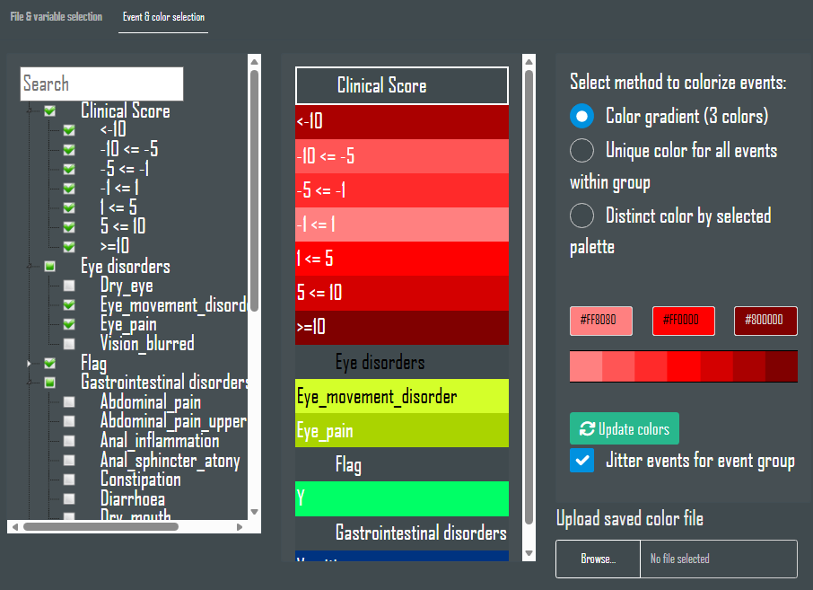

By clicking one of these events a color selection panel on the right side appears. Depending on whether a single event or a event group is clicked, the options in the color selection panel differ.

Note: If you change the event selection on the left side after making a selection for the colors in the middle, it may happen that a event/event group selection does not respond. By clicking any other event in the color list updates the selection and resolve the issue.

### Color Selection Panel

After selecting an event or event group in the color list, options to change the colors appear on the right side. There is also an jitter option to adjust the event position of the event group, which will be explained in the chapter after next.

### Color Methods

Selecting suitable colors is particularly difficult when many different events are to be represented. The user is responsible for selecting suitable colors and take color blindness into account. For the correct color selection, please refer to the various best practice guides. The methods here are only intended as an aid to their implementation.

When an event group is selected, there are three different methods to colorize the events: ‘Color gradient (3 colors)’, ‘Unique color for all events withing group’ and ‘Distinct color by selected palette’.

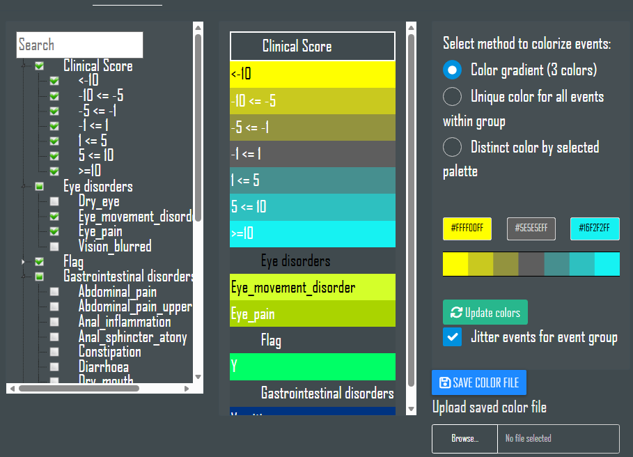

When using color gradient, three color inputs appear which will define a color palette displayed below. In this example, the colors yellow, gray and turquoise are used. Depending on how many events are there within an event group, there are that many colors, created by these three colors. By clicking one of these color inputs a color palette appears which can be used to change the colors and their saturation. However, it is also possible to directly access a color hexcode into the color box. Once a satisfactory color palette has been found, click the ‘Update colors’ button to apply the changes.

The second option ‘Unique color for all events within group’ obviously colors all events of an event group in the same color. So there will be exactly one color input. Here too, the color can be selected using the palette or by entering the hexcode.

The third option ‘Distinct color by selected palette’ brings up another drop-down menu ‘Select color palette’ where predefined color palettes can be selected. By selecting one of these palettes a good visulization is not guaranteed and must be ensured by the user.

If an single event is selected in the color list the color selection on the right will be the same for ‘Unique color for all events within group’ explained above. So it is possible to first create a color palette for the complete event group and after that change individual colors by selection the event.

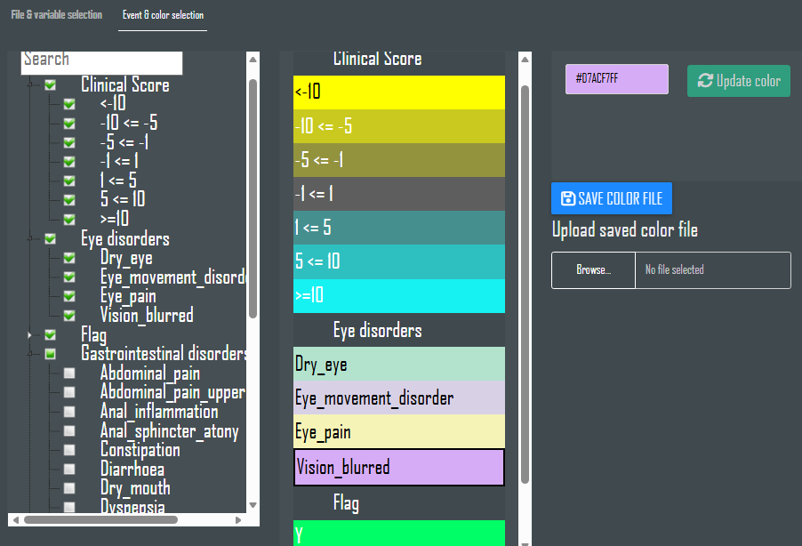

### Offset Events

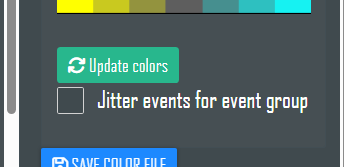

The offset position will be the same for each time course. An offset position for events within an event group only makes sense if different events at a given day can appear. For unique events within a event group, it is recommended to disable this option.

### Save & Upload Color Files

Once all color settings have been made, they can be saved via the ‘save color file’-button. This saves a data frame as ‘.rds’-file including the selected event and event group, the selected color and if available all three selected gradient color and also the logical value if variables should be offset.

To upload the saved color settings in a new session use the ‘Upload saved color file’-file input like the data upload.

## Megaplots

In this chapter the main graphical display will be explained. The megaplot is a huge graphical display used to show individual-level data over time. The megaplots uses horizontal lines to represent individual trajectories and events of any identifier over days (in clinical trial context: study units).

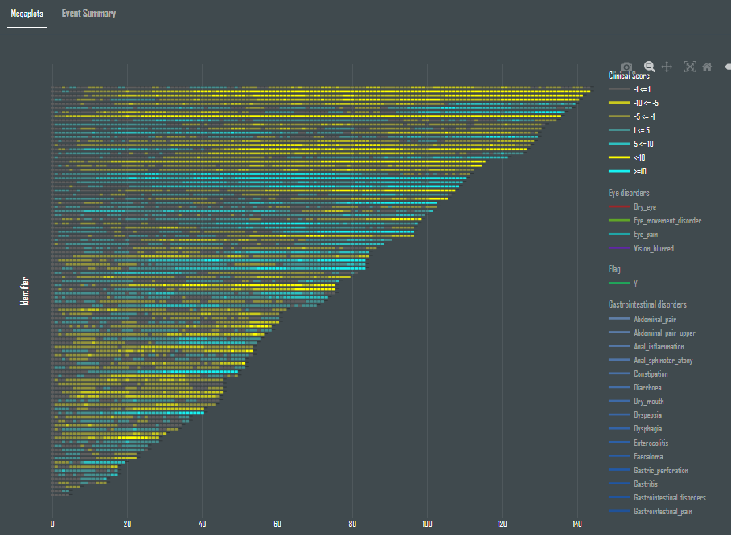

The legend on the right side can be used to select and deselect event groups to provide an better overview. Selecting a high number of events can lead to overlaying event lines. In this case it is recommended to focus on a few number of event/event groups or zoom-in on the graphic accordingly.

For every single event displayed a hover panel is available with information about the identifier, the event name as well as the start and end time. It is also possible to use the mouse hover for the individual timelines, however these are only visible when hovering near the start or end of the line.

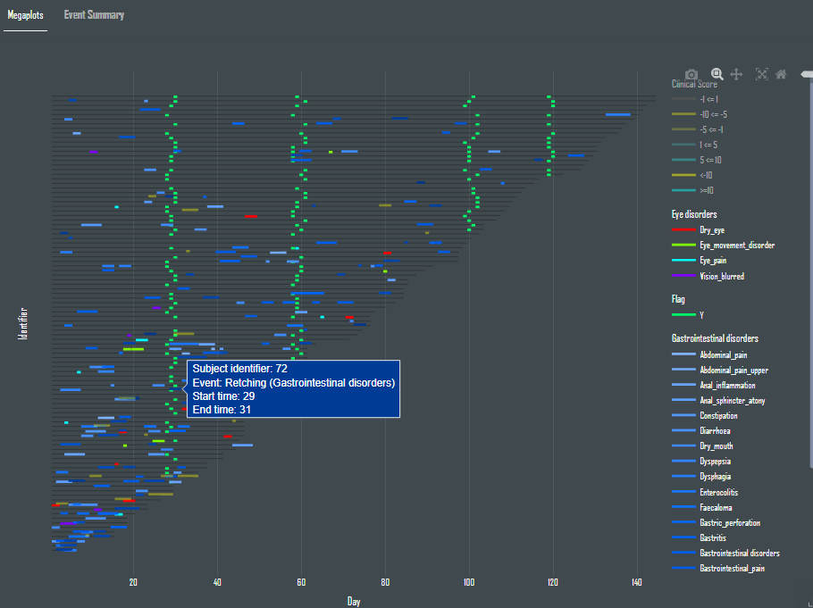

In addition to hovering, you can also click on event lines. The complete clicked event are then highlighted in comparison to other events. It is possible to click on and highlight as many events as desired. To undo the effect, double-click on the plot window.

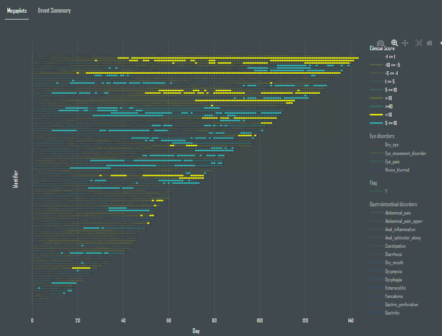

There are several ways to zoom-in to the graphic. First, it is possible to use mouse-scrolling to zoom-in. To re-scale only one axis, click and drag near the edge of one of the axes. If the drag mode is set to ‘pan’ (see chapter Plot options) it is possible to click and drag on the plot. Another zoom possibility is to click and drag on the plot when option ‘Zoom’ is selected.

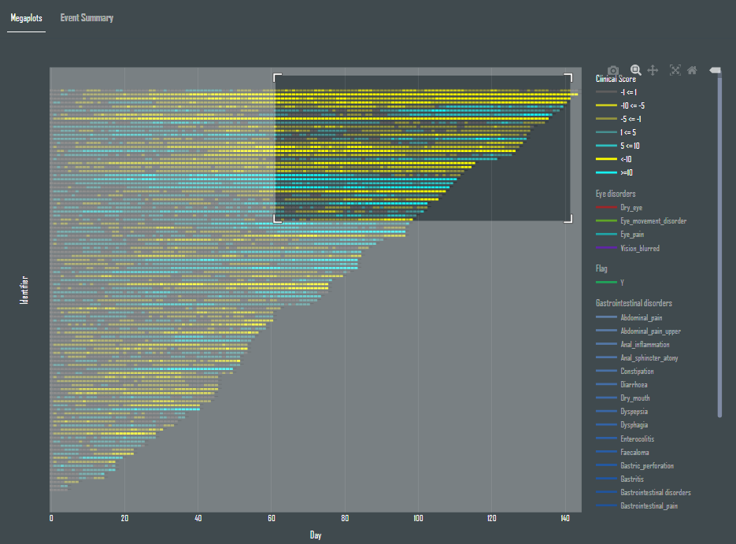

Third way to zoom is to use the ‘plus’ or ‘minus’ button on the modebar to zoom-in or zoom-out.

Further options for this megaplots graph are described in the chapter “Sidebar Options”, such as sorting, grouping or line thickness.

## Event Summary

In addition to the long-proven megaplots graph, we have included another plot in to most recent version, the so-called **Event Summary**. This prodcuces an interactive line chart that visualize how clinical trial events are distributed across study days. Each event type is rendered as a separate line, making it straightforward to judge whether a particular event tends to cluster early or late in a study. The chart is also built with plotly, so it supports interactive hover label that display exact event counts for any given day. There is also an interactive legend, to add or remove events in a snap. This makes it easy to track the number of events up to a specific day.

In the picture below a Event Summary for all kinds of events are displayed. Depending on how often the events take place, it may make sense to look at specific event groups one by one, especially when mixing common daily events with rare ones.

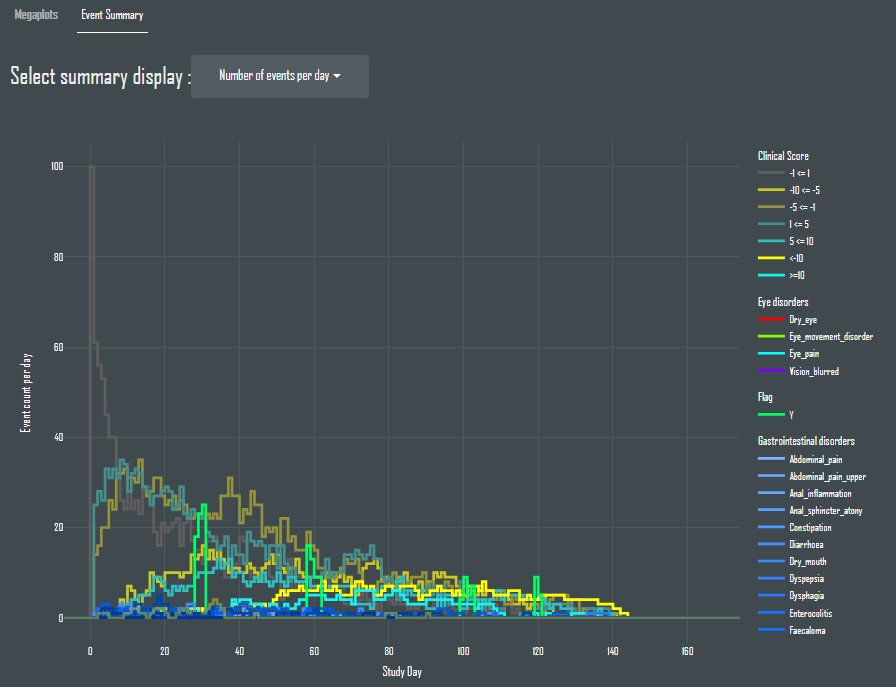

The hover functionality now works as follows: You can select a data point along the x-axis, an a vertical dashed line will appear at that point. For each event line, one small label appears, showing the corresponding event count for that day. In the plot appearance option, you can set the threshold for when events should be displayed to minimize the number of labels if there are too many events.

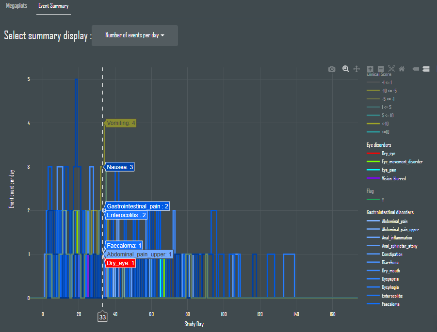

Another option is to generate one hover label with all events and event counts listed in a same way the legend is created. This option is also available in the sidebar at the Plot appearance options.

### Summary display

Above the chart is an Dropdown menu called ‘Select summary display’. The user has the option to select out of three options:

- **Number of events per day** - Shows the raw count of event occurrences on each individual study day.
- **Number of events per day (cumulative total)** - Shows the running total of all event occurrences accumulated from the start of the study.
- **Number of first events per day and subject (cumulative total)**- Like (cumulative total), but recurring events for the same subject are deduplicated — only the first occurrence per subject per event type is counted. The default is **Number of events per day**, which is the most suitable starting point for spotting temporal clustering.

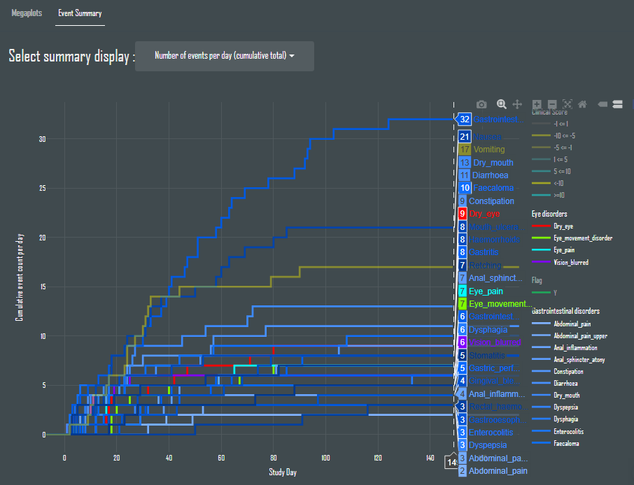

As for the Megaplot chart, there is also the option to group the **Event Summary** by one or multiple variables. This feature makes it easy to compare different groups. Unfortunately, hovering and zooming only works for one group at a time. Also keep in mind, that y-axes may differ after zooming in one grouped graph.

## Sidebar Options

Various options are available on the sidebar, which would be ‘Sorting/Grouping’, ‘Plot appearance’, ‘Filter’ and ‘Download’. Each of these option panels is explained in a separate chapter below.

### Sorting / Grouping

When you click on ‘Sorting/Grouping’, a panel opens with the three inputs: ‘Sorting variable’, ‘Grouping variable’ and ‘Arrange Groups’. In the sorting variable input, every numeric variable of the uploaded data set is eligible. Therefore custom sorting variables can be created in the data preparation.

All character variables in the upload data can be used as a grouping variable. If a grouping variable is selected, the time-courses are splitted by all variable values.

[figure not shown]

It is also possibly to select multiple grouping variables. Then the option ‘Arrange groups’ might be of interest, as it allows the groups to be reordered. This can be done simply by drag and drop the displayed group boxes.

[figure not shown]

### Plot Appearance

A wide variety of options related to appearance can be found here. Changing one of the option in the **Plot appearance** panel re-renders the graphs. For charts with a large number of events and high render times,and if you need to change multiple options, it may be faster to first deselect all events.

The first one is a drag and drop feature to re-arrange the order of which the event lines are drawn. It is strongly recommended to sort rare or important events to the bottom of this list to ensure they remain visible.

The next feature is an color option to change the color and/or its transparency of the subject line. Depending on which theme is selected at the top right corner, the user has to change the corresponding color.

The width of the subject time line as well as the width of the events lines can be changed via slider.

The toggle switch for **Legend Grouping** determines, whether entire event groups are selected in the legend or only individual events. The appropriate option depends on the specific situation. If events of groups events are only display together and need to be deselected quickly, **Legend Grouping** is the better choice. If individual events are to be selected, this option can be turned off to compare individual events with one another.

The two remaining options are for the **Event Summary** chart and are explained there. The first one changed the hover label appearance and the second one determines for which treshold, the labels should appear.

### Reference Lines/Rectangles

In the older megaplot version, there was an option to draw reference lines into the megaplot chart. We have adopted this option and are expanding on it in the sense that it is now also possible to draw rectangles in the background. The setup is simple. Simply check “Add reference rectangle”, select a color (+transparancy), select an x-axis start value (x1) and an x-axis end value (x2). If the same number for x1 and x2 is entered, a vertical line at this specific day will be drawn. If different values are entered, then a rectangle is drawn in the background. So far, up to 3 different lines or background rectangles can be drawn. This can therefore serve as a helpful visual reference for defining specific time periods or marking an important day for analysis.

### Filter

The filter panel uses the datamods package which provides custom modules and one of them is to produce the filters. This makes it easy to filter your data set fast and simple.

With the selection box **Select filter variable(s)** all variables can be selected and for the selected variables further options will appear. Every selected numeric variable will create a slider and every character variable with create a selection box. If the variables includes missing values (NAs), there is also a little switch to include or exclude NAs for the variable. After all filter selection where made, the charts updating with the reduced/filtered data set.

### HTML Download

This panel currently contains exactly one button “Download Mega plot as HTML”. So when you click it, the megaplot chart can be saved in HTML format. All plotly options are preserved in this file, but app options like sorting and grouping are of course not available.

## Additional information

To use the full screen size for your megaplot hide sidebar, if not used.